# Homework 06

## Setup

Split and standardization.

```r
library(ggplot2)

path <- if (file.exists("data/breast-cancer.csv")) "data/breast-cancer.csv" else "breast-cancer.csv"
dat  <- read.csv(path)
predictors <- c("mean_radius", "mean_texture", "mean_smoothness")
stopifnot(all(c(predictors, "y") %in% names(dat)), !anyNA(dat))

# 70/30 split
set.seed(2024)
train_idx <- sample(nrow(dat), size = round(0.7 * nrow(dat)))
train <- dat[train_idx, ]
test  <- dat[-train_idx, ]

mu  <- colMeans(train[predictors])
sdv <- apply(train[predictors], 2, sd)
X_train <- scale(train[predictors], center = mu, scale = sdv)
X_test  <- scale(test[predictors],  center = mu, scale = sdv)
y_train <- train$y
y_test  <- test$y

knn_prob <- function(X_ref, y_ref, X_new, k) {
  n_new <- nrow(X_new)
  D <- as.matrix(dist(rbind(X_new, X_ref)))[seq_len(n_new), n_new + seq_len(nrow(X_ref)), drop = FALSE]
  apply(D, 1, function(d) mean(y_ref[order(d)[seq_len(k)]]))
}

# ROC curve
roc_curve <- function(score, y) {
  thr <- sort(unique(score), decreasing = TRUE)
  data.frame(fpr = c(0, sapply(thr, function(t) mean(score[y == 0] >= t))),
             tpr = c(0, sapply(thr, function(t) mean(score[y == 1] >= t))))
}
# AUC
auc <- function(roc) sum(diff(roc$fpr) * (head(roc$tpr, -1) + tail(roc$tpr, -1)) / 2)
```

## Question 1: Compare KNN and logistic regression

Use breast-cancer.csv, which contains 569 cases from the [Wisconsin Diagnostic Breast Cancer dataset](https://archive.ics.uci.edu/dataset/17/breast%2Bcancer%2Bwisconsin%2Bdiagnostic). Predict `y` (1 for malignant and 0 for benign) using `mean_radius`, `mean_texture`, and `mean_smoothness`.

Set a random seed and randomly split the observations into 70% training and 30% test data. Use the same split for every model. Standardize the predictors using the training means and standard deviations, and apply the same transformations to the test data.

Fit ordinary logistic regression with an intercept and no penalty, and KNN with Euclidean distance, equal neighbor weights, and

$$k\in\{5,15,25,35,45\}.$$

Using the estimated probabilities for `y = 1` on the test data, plot all six ROC curves in one figure and report their AUC values. Which of the six fitted models do you prefer? Give a brief justification based on your results.

## Solution - q1

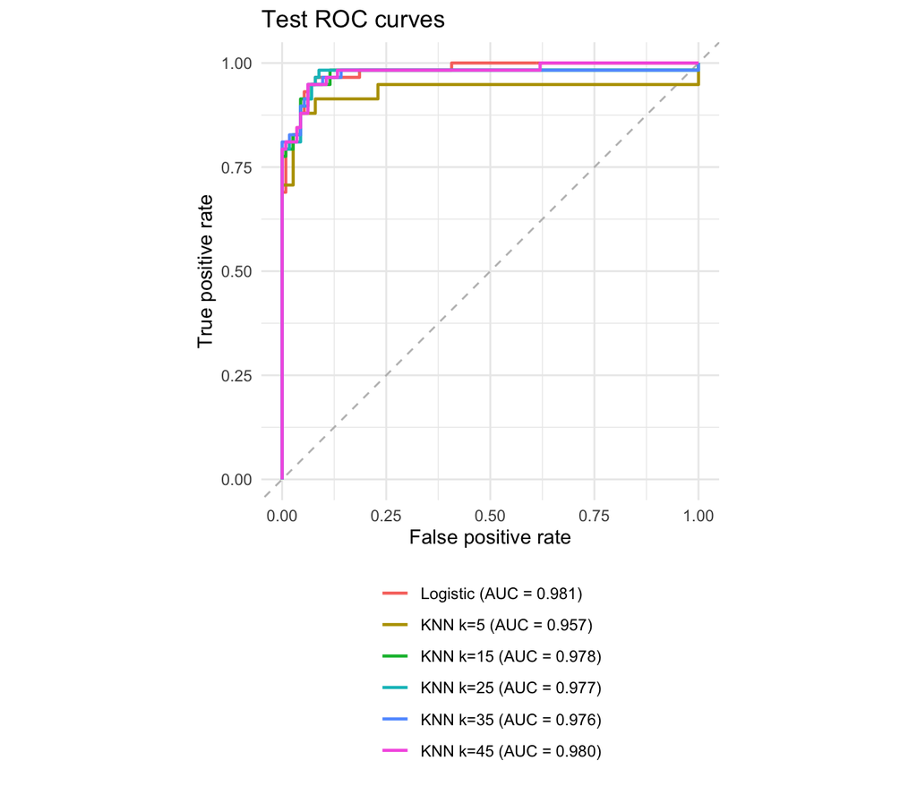

```r
# Logistic regression
fit_lr <- glm(y ~ ., data = data.frame(y = y_train, X_train), family = binomial)
scores <- list("Logistic" = predict(fit_lr, newdata = data.frame(X_test), type = "response"))

# KNN
ks1 <- c(5, 15, 25, 35, 45)
for (k in ks1) scores[[paste0("KNN k=", k)]] <- knn_prob(X_train, y_train, X_test, k)

rocs1 <- lapply(scores, roc_curve, y = y_test)
auc1  <- sapply(rocs1, auc)
lab1  <- sprintf("%s (AUC = %.3f)", names(rocs1), auc1)

plot1 <- do.call(rbind, Map(function(r, l) cbind(r, model = l), rocs1, lab1))
plot1$model <- factor(plot1$model, levels = lab1)

ggplot(plot1, aes(fpr, tpr, color = model)) +
  geom_abline(linetype = "dashed", color = "grey") +
  geom_step(linewidth = 0.8) +
  coord_equal() +
  labs(title = "Test ROC curves", x = "False positive rate", y = "True positive rate", color = NULL) +
  theme_minimal() + theme(legend.position = "bottom", legend.direction = "vertical")
```

```r
data.frame(Model = names(auc1), Test_AUC = round(auc1, 4), row.names = NULL)
```

```
     Model Test_AUC
1 Logistic   0.9809
2  KNN k=5   0.9573
3 KNN k=15   0.9780
4 KNN k=25   0.9767
5 KNN k=35   0.9756
6 KNN k=45   0.9801
```

## Question 2: Training and test ROC curves

Use the same data, training/test split, and standardization as in Question 1. Fit KNN with Euclidean distance, equal neighbor weights, and

$$k\in\{1,3,5,10,20\}.$$

Use each fitted model to estimate probabilities for both the training and test observations. For training predictions, include each observation itself among its $k$ nearest neighbors.

For each $k$, use a separate panel to show the training and test ROC curves together. Report both AUC values.

Explain the difference between training and test performance and how it changes with $k$. In particular, explain what happens at $k=1$ and why training performance may not reflect performance on new observations.

## Solution -q2

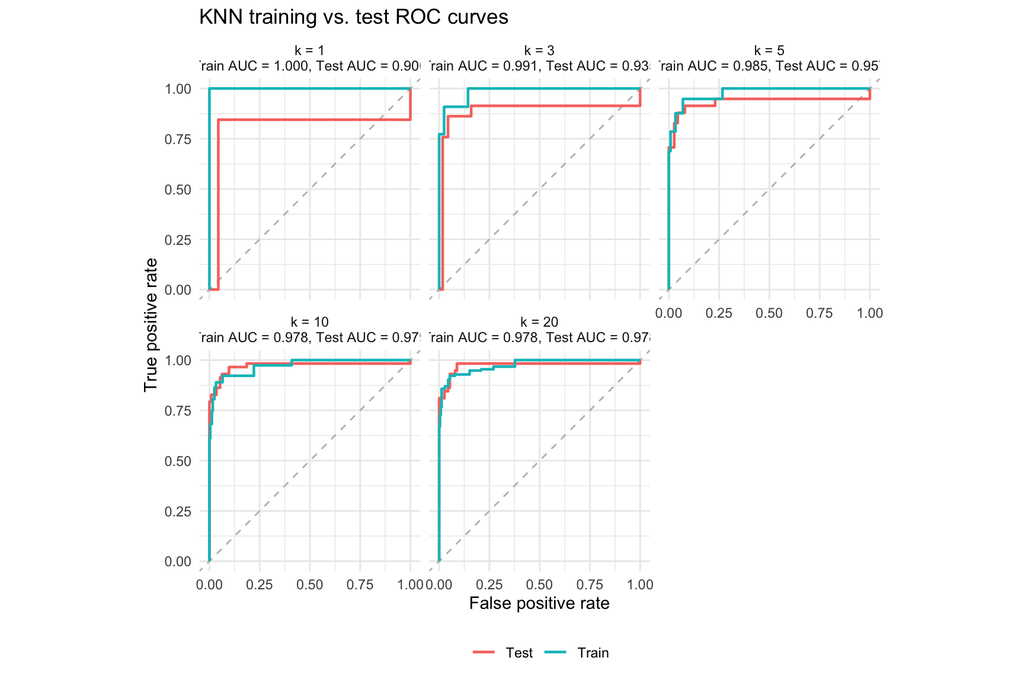

```r
ks2 <- c(1, 3, 5, 10, 20)

res2 <- lapply(ks2, function(k) {
  r_tr <- roc_curve(knn_prob(X_train, y_train, X_train, k), y_train)  # each point is its own neighbor
  r_te <- roc_curve(knn_prob(X_train, y_train, X_test,  k), y_test)
  list(auc = c(Train = auc(r_tr), Test = auc(r_te)),
       roc = rbind(cbind(r_tr, set = "Train"), cbind(r_te, set = "Test")))
})

panel_lab <- sprintf("k = %d\nTrain AUC = %.3f, Test AUC = %.3f",
                     ks2, sapply(res2, function(r) r$auc["Train"]), sapply(res2, function(r) r$auc["Test"]))
plot2 <- do.call(rbind, Map(function(r, l) cbind(r$roc, panel = l), res2, panel_lab))
plot2$panel <- factor(plot2$panel, levels = panel_lab)

ggplot(plot2, aes(fpr, tpr, color = set)) +
  geom_abline(linetype = "dashed", color = "grey") +
  geom_step(linewidth = 0.8) +
  facet_wrap(~ panel, ncol = 3) +
  coord_equal() +
  labs(title = "KNN training vs. test ROC curves", x = "False positive rate", y = "True positive rate", color = NULL) +
  theme_minimal() + theme(legend.position = "bottom")
```

```r
auc2 <- data.frame(k = ks2, Train_AUC = sapply(res2, function(r) r$auc["Train"]),
                   Test_AUC = sapply(res2, function(r) r$auc["Test"]))
auc2$Gap <- auc2$Train_AUC - auc2$Test_AUC
round(auc2, 4)
```

```
   k Train_AUC Test_AUC     Gap
1  1    1.0000   0.9003  0.0997
2  3    0.9907   0.9348  0.0558
3  5    0.9853   0.9573  0.0281
4 10    0.9780   0.9789 -0.0008
5 20    0.9783   0.9780  0.0004
```

Training AUC is higher than test AUC for small $k$, and the gap closes as $k$ increases (at about 0.100 at $k=1$, 0.056 at $k=3$, 0.028 at $k=5$, and ~0 for $k=10$ and $k=20$).

At $k=1$, each training point’s nearest neighbor is itself, so its predicted probability is exactly its own label. This produces a perfect training ROC curve (AUC = 1) regardless of how well the model would predict new cases. The test AUC at $k=1$ is only 0.900, because a single neighbor makes predictions very noisy and the model overfits to individual training points. As $k$ grows, each prediction averages over more neighbors, so a point’s own label has less influence on its prediction. Training and test performance then converge, and test AUC rises to about 0.978 by $k=10$ to $20$.

Training performance therefore does not reflect performance on new observations, especially for flexible models like small-$k$ KNN, because the training predictions are partly “memorized” from the same labels being evaluated. Test data, which the model has not seen, gives the honest estimate.

## Question 3: Peer evaluation of Homework 5

You will receive two Homework 5 submissions to review. The instructor’s GitHub account, **rqzhu-aide**, will open a **GitHub Issue** in the repository containing your Homework 5 submission. It will contain links to two other students’ repositories, where you can find their submitted homework reports.

Open your repository’s **Issues** tab on GitHub to find the assignment. You may ask AI to explain GitHub Issues or help you locate the assignment.

Choose **one specific mistake or item for improvement** from any question in either report.

1. **Identify the mistake or item for improvement.** State which report and question you selected, and briefly describe what is wrong or could be improved. Examples include incorrect code, a calculation error, a misinterpretation of results, a plot that could communicate the findings more clearly, or anything else you think could be done better.
2. **Explain your assessment.** Quote the relevant text, code, or figure caption exactly. Explain why the selected answer is incorrect or how it could be improved, referring to its reasoning, calculations, code, figures, or interpretation. **Complete this part yourself, without AI assistance.**
3. **Provide a correction.** Write a corrected or improved answer to the selected question, including any calculations, code, or figures needed.

After completing your review, **open a GitHub Issue in the repository containing the report you selected**. Identify the report and question, and include your assessment and a detailed revision plan explaining what the author should change and why. Include a link to your posted GitHub Issue in your Homework 6 answer.

## Question 3

I selected my peer ryanskim’s report. I found an issue in their Homework 05 Question 4a) submission. Specifically this code: man_dist <- function(x_0, X) { sqrt(rowSums(sweep(X, 2, x_0, “-”)))}. The man_dist calculated here is not finding Manhattan distance as defined in the problem, so the Manhattan classifier’s predictions in 4b and 4c are not valid. This has no abs(), and it takes a square root. The formula is d_M = Σ|x₀ⱼ − xᵢⱼ|. So the neighbor ranking doesn’t make sense: The code to fix this would follow the formula, something like: man_dist <- function(x_0, X) { rowSums(abs(sweep(X, 2, x_0, “-”))) }. Then the later figures would have to be recalculated as well to ensure correct outcomes.

[Link to issue](https://github.com/ryanskim04/stat432-fall2026/issues/3)